# Презентация по выполнению индивидуального проекта №2

Основы информационной безопасности

Назармамадов У. Дж.

Российский университет дружбы народов, Москва, Россия

21 сентября 2025

# Информация

## Докладчик

- Назармамадов Умед Джамшедович
- студент группы НКАбд-03-23
- Российский университет дружбы народов

# Цель

Приобретение практических навыков по установке DVWA.

## 1.1

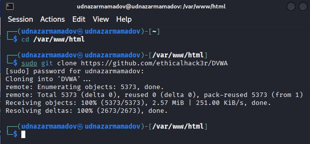

## 1.2

Проверяю, что файлы склонировались правильно, далее повышаю права доступа к этой папке до 777

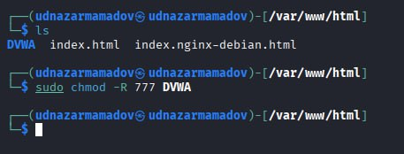

## 1.3

Чтобы настроить DVWA, нужно перейти в каталог /dvwa/config, затем проверяю содержимое каталога

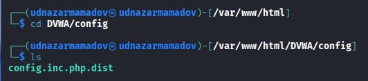

## 1.4

Создаем копию файла, используемого для настройки DVWA config.inc.php.dist с именем config.inc.php. Копируем файл, а не изменяем его, чтобы у нас был запасной вариант, если что-то пойдет не так

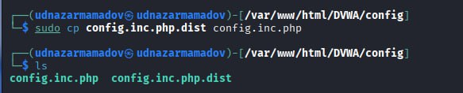

## 1.5

Далее открываю файл в текстовом редакторе

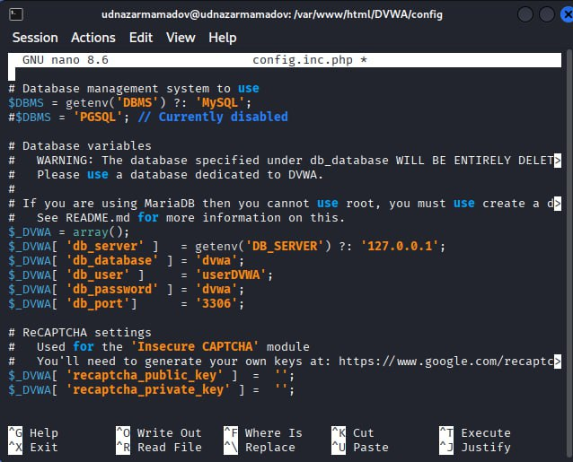

##2.1

Изменяю данные об имени пользователя и пароле

[figure not shown]

## 2.2

По умолчанию в Kali Linux установлен mysql, поэтому можно его запустить без предварительного скачивания, далее выполняю проверку, запущен ли процесс

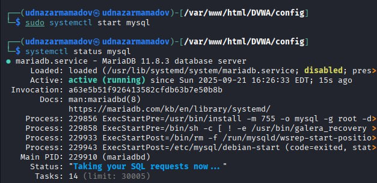

## 2.3

Авторизируюсь в базе данных от имени пользователя root. Появляется командная строка с приглашением “MariaDB”, далее создаем в ней нового пользователя, используя учетные данные из файла config.inc.php

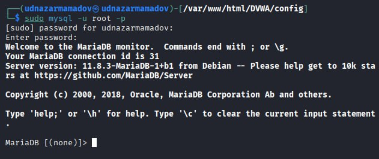

## 2.4

Теперь нужно пользователю предоставить привилегии для работы с этой базой данных

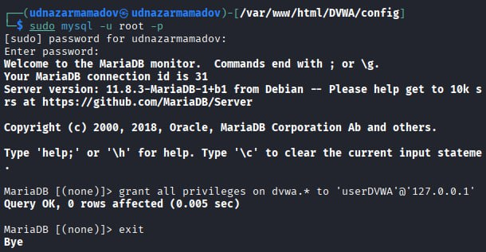

## 2.5

Необходимо настроить сервер apache2, перехожу в соответствующую директорию

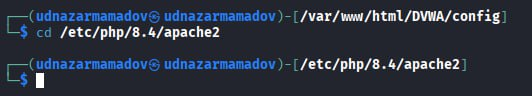

## 3.1

В файле php.ini нужно будет изменить один параметр, поэтому открываю файл в текстовом редакторе

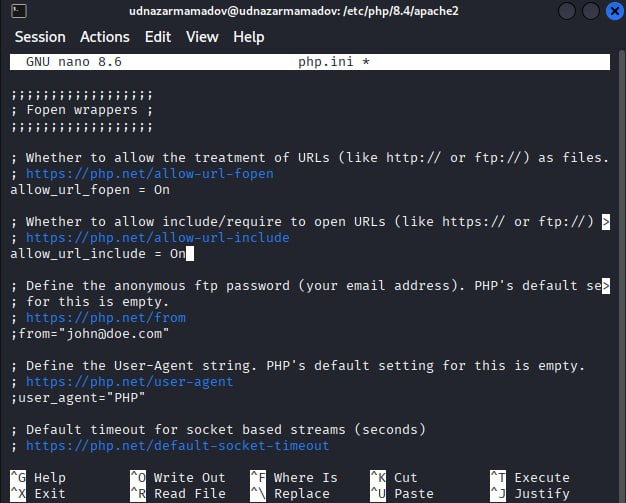

## 3.2

В файле параметры allow_url_fopen и allow_url_include должны быть поставлены как On

[figure not shown]

## 3.3

Запускаем службу веб-сервера apache и проверяем, запущена ли служба

[figure not shown]

## 3.4

Мы настроили DVWA, Apache и базу данных, поэтому открываем браузер и запускаем веб-приложение, введя 127.0.0/DVWA

[figure not shown]

## 3.5

Прокручиваем страницу вниз и нажимем на кнопку create/reset database

[figure not shown]

## 4.1

Авторизуюсь с помощью предложенных по умолчанию данных

[figure not shown]

## 4.2

Оказываюсь на домшней странице веб-приложения, на этом установка окончена

[figure not shown]

# Вывод

Приобрел практические навыки по установке уязвимого веб-приложения DVWA.